# runs&wins

mateo sarabia

2024-10-31

Finding the relationship between runs and wins in the MLB.

```r
library(tidyverse)
library(janitor)
library(here)
```

```r
library(readr)
library(ggplot2)
library(ggrepel)
library(Lahman)
library(broom)
```

```r
tail(Teams,)
```

```
##      yearID lgID teamID franchID divID Rank   G Ghome  W  L DivWin WCWin LgWin
## 3040   2023   NL    PHI      PHI     E    2 162    81 90 72      N     Y     N
## 3041   2023   NL    PIT      PIT     C    4 162    81 76 86      N     N     N
## 3042   2023   NL    SDN      SDP     W    3 162    81 82 80      N     N     N
## 3043   2023   NL    SFN      SFG     W    4 162    81 79 83      N     N     N
## 3044   2023   NL    SLN      STL     C    5 162    81 71 91      N     N     N
## 3045   2023   NL    WAS      WSN     E    5 162    81 71 91      N     N     N
##      WSWin   R   AB    H X2B X3B  HR  BB   SO  SB CS HBP SF  RA  ER  ERA CG SHO
## 3040     N 796 5541 1417 291  29 220 539 1481 141 26  69 42 715 646 4.03  1   1
## 3041     N 692 5406 1293 287  31 159 556 1464 117 41  58 43 790 731 4.60  2   2
## 3042     N 752 5401 1316 273  14 205 653 1311 137 32  57 44 648 598 3.73  0   0
## 3043     N 674 5412 1271 256  13 174 544 1492  57 16  81 39 719 641 4.02  4   2
## 3044     N 719 5510 1376 264  12 209 570 1326 101 29  70 37 829 760 4.79  0   0
## 3045     N 700 5522 1401 279  26 151 423 1149 127 29  78 38 845 797 5.02  0   0
##      SV IPouts   HA HRA BBA  SOA   E  DP    FP                  name
## 3040 45   4327 1318 185 470 1454  91 309 0.984 Philadelphia Phillies
## 3041 47   4290 1380 179 596 1363  91 360 0.984    Pittsburgh Pirates
## 3042 36   4323 1270 174 557 1445  73 356 0.988      San Diego Padres
## 3043 50   4304 1395 173 403 1359 117 399 0.981  San Francisco Giants
## 3044 36   4285 1549 179 530 1215  67 431 0.989   St. Louis Cardinals
## 3045 42   4285 1512 245 592 1225  90 430 0.985  Washington Nationals
##                    park attendance BPF PPF teamIDBR teamIDlahman45 teamIDretro
## 3040 Citizens Bank Park    3052605  98  98      PHI            PHI         PHI
## 3041           PNC Park    1630624  99 101      PIT            PIT         PIT
## 3042         PETCO Park    3271554  94  93      SDP            SDN         SDN
## 3043          AT&T Park    2500153  96  96      SFG            SFN         SFN
## 3044  Busch Stadium III    3241091  99  99      STL            SLN         SLN
## 3045     Nationals Park    1865832  96  98      WSN            MON         WAS
```

```r
help("Teams")
view(Teams)
```

```r
my_teams <- Teams %>%
  filter(yearID > 2003) %>%
  select(teamID,yearID,lgID,G,W,L,R,RA)
my_teams %>%
tail()
```

```
##     teamID yearID lgID   G  W  L   R  RA
## 595    PHI   2023   NL 162 90 72 796 715
## 596    PIT   2023   NL 162 76 86 692 790
## 597    SDN   2023   NL 162 82 80 752 648
## 598    SFN   2023   NL 162 79 83 674 719
## 599    SLN   2023   NL 162 71 91 719 829
## 600    WAS   2023   NL 162 71 91 700 845
```

```r
my_teams <- my_teams %>%
  mutate(RD = R - RA, Wpct = W / (W + L))
```

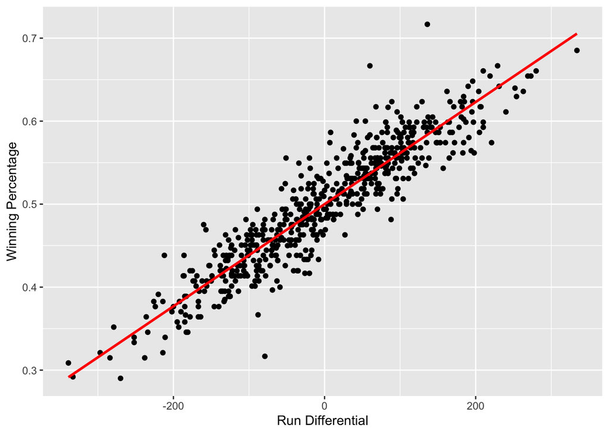

```r
run_diff <- ggplot(my_teams, aes(x = RD, y = Wpct)) + geom_point() + geom_smooth(method = "lm", se = FALSE, color = 'red') + scale_x_continuous("Run Differential") + scale_y_continuous("Winning Percentage")


plot(run_diff)
```

```r
linfit <- lm(Wpct ~ RD, data = my_teams)
linfit
```

```
##
## Call:
## lm(formula = Wpct ~ RD, data = my_teams)
##
## Coefficients:
## (Intercept)           RD
##   0.4999810    0.0006151
```

```r
my_teams_augmented <- augment(linfit, data = my_teams)
```

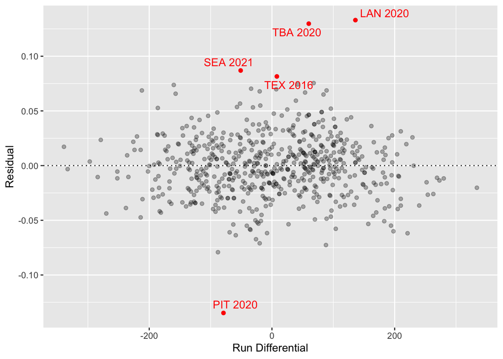

```r
base_plot <- ggplot(my_teams_augmented, aes(x = RD, y = .resid)) + geom_point(alpha = 0.3) + geom_hline(yintercept = 0, linetype = 3) + xlab("Run Differential") + ylab("Residual")

highlight_teams <- my_teams_augmented %>%
  arrange(desc(abs(.resid))) %>%
  head(5)

base_plot + geom_point(data = highlight_teams, color = 'red') + geom_text_repel(data = highlight_teams, color = 'red', aes(label = paste(teamID, yearID)))
```

```r
resid_summary <- my_teams_augmented %>%
  summarize(N=n(), avg = mean(.resid),
            RMSE = sqrt(mean(.resid^2)))
resid_summary
```

```
## # A tibble: 1 × 3
##       N      avg   RMSE
##   <int>    <dbl>  <dbl>
## 1   600 1.60e-15 0.0285
```

```r
rmse <- resid_summary %>%
  pull(RMSE)
```

```r
my_teams_augmented %>%
  summarize(N = n(),
            within_one = sum(abs(.resid) < rmse),
            within_two = sum(abs(.resid) < 2 * rmse)) %>%
  mutate(within_one_pct = within_one / N,
         within_two_pct = within_two / N)
```

```
## # A tibble: 1 × 5
##       N within_one within_two within_one_pct within_two_pct
##   <int>      <int>      <int>          <dbl>          <dbl>
## 1   600        432        571           0.72          0.952
```

The pythagorean formula for win % non-linear model to estimate win percentage

Wpct = R^2 / R^2 + RA^2

```r
my_teams <- my_teams %>%
  mutate(Wpct_pyt = R^2 / (R^2 + RA^2))
```

```r
my_teams <- my_teams %>%
  mutate(residuals_pyt = Wpct - Wpct_pyt)
my_teams %>%
  summarize(rsme = sqrt(mean(residuals_pyt^2)))
```

```
##         rsme
## 1 0.02695098
```

final notes: not always more accurate, but there are situations where it is more applicable than the linear model.

```r
my_teams <- my_teams %>%
  mutate(logWratio = log(W / L),
         logRratio = log(R / RA))

pytFit <- lm(logWratio ~ 0 + logRratio, data = my_teams)
pytFit
```

```
##
## Call:
## lm(formula = logWratio ~ 0 + logRratio, data = my_teams)
##
## Coefficients:
## logRratio
##     1.801
```

this number solved above shows what value would give a more accurate prediction with my data rather than using ^2 in the formula

rmse = root mean square error rmse in linear model: 0.02845697  
rmse in pythagorean model: 0.02695098

final notes: not always more accurate, but there are situations where it is more applicable than the linear model.

How many runs for a win?

```r
D (expression(G * R ^2 / (R^2 + RA ^2)), "R")
```

```
## G * (2 * R)/(R^2 + RA^2) - G * R^2 * (2 * R)/(R^2 + RA^2)^2
```

```r
IR <- function(RS = 5, RA = 5) {
  (RS^2 + RA)^2 / (2*RS*RA^2)
}
```

```r
ir_table <- expand.grid(RS = seq(3, 6, .5),
                        RA = seq(3, 6, .5))
head(ir_table)
```

```
##    RS RA
## 1 3.0  3
## 2 3.5  3
## 3 4.0  3
## 4 4.5  3
## 5 5.0  3
## 6 5.5  3
```

```r
tail(ir_table)
```

```
##     RS RA
## 44 3.5  6
## 45 4.0  6
## 46 4.5  6
## 47 5.0  6
## 48 5.5  6
## 49 6.0  6
```

```r
ir_table %>%
  mutate(IRW = IR(RS, RA)) %>%
  spread(key = RA, value = IRW, sep = "=") %>%
  round(1)
```

```
##    RS RA=3 RA=3.5 RA=4 RA=4.5 RA=5 RA=5.5 RA=6
## 1 3.0  2.7    2.1  1.8    1.5  1.3    1.2  1.0
## 2 3.5  3.7    2.9  2.4    2.0  1.7    1.5  1.3
## 3 4.0  5.0    3.9  3.1    2.6  2.2    1.9  1.7
## 4 4.5  6.7    5.1  4.1    3.4  2.8    2.4  2.1
## 5 5.0  8.7    6.6  5.3    4.3  3.6    3.1  2.7
## 6 5.5 11.2    8.5  6.7    5.4  4.5    3.8  3.3
## 7 6.0 14.1   10.6  8.3    6.8  5.6    4.7  4.1
```

- Next: take a look at the 2020 season and use the model to find expected win percentage and use that to compute the expected win amount. Then look at either 2019 or 2021 to see the differences in the shortened season bc of covid so how did that affect teams. Which did it help? Which did it hurt? why did some teams outperform themselves when others didn’t? what are some data points that stick out? *

```r
my_teams2020 <- Teams %>%
  filter(yearID == 2020) %>%
  select(teamID,yearID,lgID,G,W,L,R,RA)
my_teams %>%
tail()
```

```
##     teamID yearID lgID   G  W  L   R  RA   RD      Wpct  Wpct_pyt residuals_pyt
## 595    PHI   2023   NL 162 90 72 796 715   81 0.5555556 0.5534533   0.002102281
## 596    PIT   2023   NL 162 76 86 692 790  -98 0.4691358 0.4341610   0.034974760
## 597    SDN   2023   NL 162 82 80 752 648  104 0.5061728 0.5738780  -0.067705189
## 598    SFN   2023   NL 162 79 83 674 719  -45 0.4876543 0.4677293   0.019925023
## 599    SLN   2023   NL 162 71 91 719 829 -110 0.4382716 0.4292976   0.008974029
## 600    WAS   2023   NL 162 71 91 700 845 -145 0.4382716 0.4069683   0.031303311
##       logWratio   logRratio
## 595  0.22314355  0.10731664
## 596 -0.12361396 -0.13244699
## 597  0.02469261  0.14884563
## 598 -0.04939276 -0.06463125
## 599 -0.24817963 -0.14235880
## 600 -0.24817963 -0.18825629
```

```r
my_teams2020 <- my_teams2020 %>%
  mutate(RD = R - RA, Wpct = W / (W + L))
```

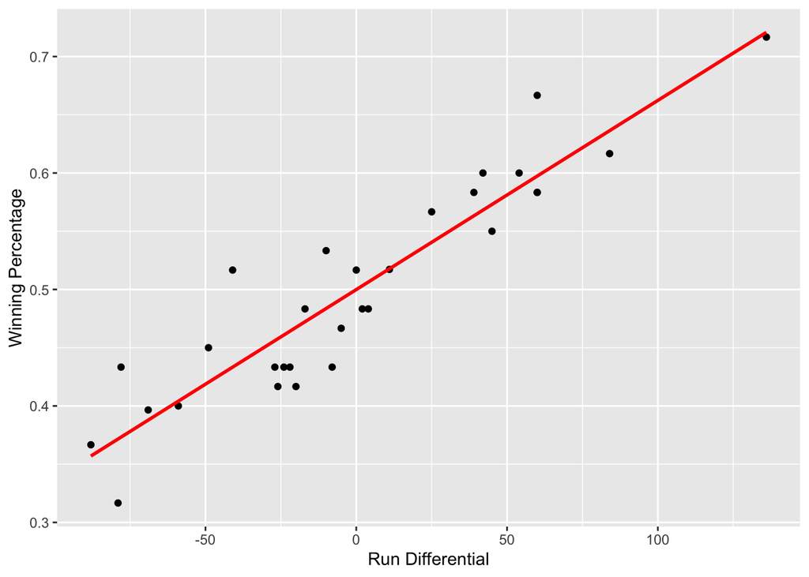

```r
run_diff <- ggplot(my_teams2020, aes(x = RD, y = Wpct)) + geom_point() + geom_smooth(method = "lm", se = FALSE, color = 'red') + scale_x_continuous("Run Differential") + scale_y_continuous("Winning Percentage")


plot(run_diff)
```

```r
linfit1 <- lm(Wpct ~ RD, data = my_teams2020)
linfit1
```

```
##
## Call:
## lm(formula = Wpct ~ RD, data = my_teams2020)
##
## Coefficients:
## (Intercept)           RD
##    0.499904     0.001624
```

```r
my_teams_augmented_covid <- augment(linfit1, data = my_teams2020)
```

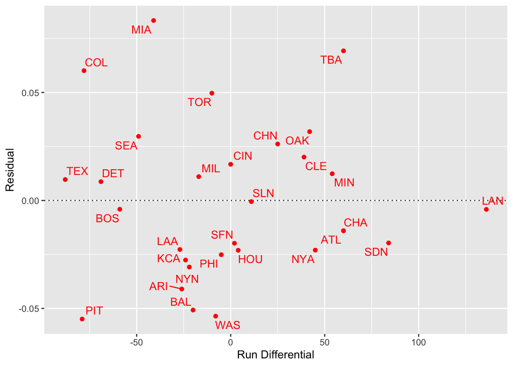

```r
base_plot <- ggplot(my_teams_augmented_covid, aes(x = RD, y = .resid)) + geom_point(alpha = 0.3) + geom_hline(yintercept = 0, linetype = 3) + xlab("Run Differential") + ylab("Residual")

highlight_teams <- my_teams_augmented_covid %>%
  arrange(desc(abs(.resid))) %>%
  head(30)

base_plot + geom_point(data = highlight_teams, color = 'red') + geom_text_repel(data = highlight_teams, color = 'red', aes(label = paste(teamID)))
```

[figure not shown]

```r
base_plot <- ggplot(my_teams_augmented_covid, aes(x = RD, y = .resid*162)) + geom_point(alpha = 0.3) + geom_hline(yintercept = 0, linetype = 3) + xlab("Run Differential (2020)") + ylab("Predicted to Actual Wins (2020)")

highlight_teams <- my_teams_augmented_covid %>%
  arrange(desc(abs(.resid*162))) %>%
  head(30)

base_plot + geom_point(data = highlight_teams, color = 'black') + geom_text_repel(data = highlight_teams, color = 'red', aes(label = paste(teamID)))
```

2021 data:

```r
my_teams2021 <- Teams %>%
  filter(yearID == 2021) %>%
  select(teamID,yearID,lgID,G,W,L,R,RA)
my_teams2021 %>%
tail()
```

```
##    teamID yearID lgID   G   W   L   R  RA
## 25    PHI   2021   NL 162  82  80 734 745
## 26    PIT   2021   NL 162  61 101 609 833
## 27    SDN   2021   NL 162  79  83 729 708
## 28    SFN   2021   NL 162 107  55 804 594
## 29    SLN   2021   NL 162  90  72 706 672
## 30    WAS   2021   NL 162  65  97 724 820
```

```r
my_teams2021 <- my_teams2021 %>%
  mutate(RD = R - RA, Wpct = W / (W + L))
```

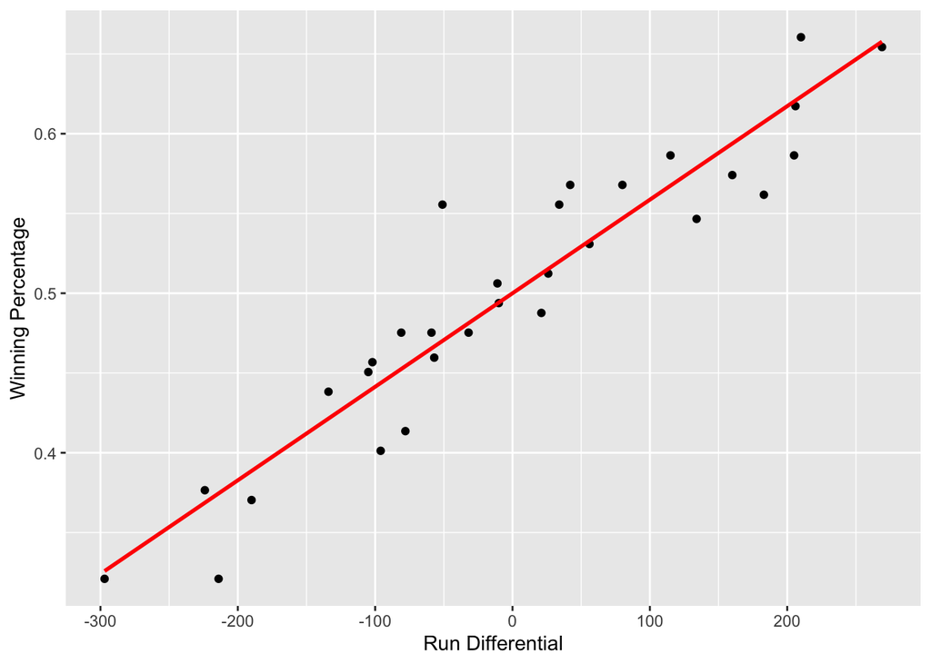

```r
run_diff <- ggplot(my_teams2021, aes(x = RD, y = Wpct)) + geom_point() + geom_smooth(method = "lm", se = FALSE, color = 'red') + scale_x_continuous("Run Differential") + scale_y_continuous("Winning Percentage")


plot(run_diff)
```

```r
linfit2 <- lm(Wpct ~ RD, data = my_teams2021)
linfit2
```

```
##
## Call:
## lm(formula = Wpct ~ RD, data = my_teams2021)
##
## Coefficients:
## (Intercept)           RD
##   0.5000013    0.0005863
```

```r
my_teams_augmented_2021 <- augment(linfit2, data = my_teams2021)
```

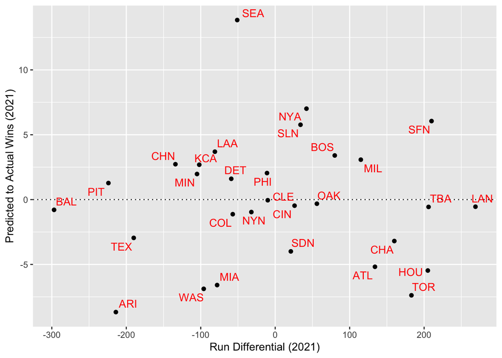

```r
base_plot <- ggplot(my_teams_augmented_2021, aes(x = RD, y = .resid*162)) + geom_point(alpha = 0.3) + geom_hline(yintercept = 0, linetype = 3) + xlab("Run Differential (2021)") + ylab("Predicted to Actual Wins (2021)")

highlight_teams <- my_teams_augmented_2021 %>%
  arrange(desc(abs(.resid*162))) %>%
  head(30)

base_plot + geom_point(data = highlight_teams, color = 'black') + geom_text_repel(data = highlight_teams, color = 'red', aes(label = paste(teamID)))
```

```r
my_teams_augmented_covid <- my_teams_augmented_covid %>%
  mutate(xGW = .resid*60, xW = xGW + W)
```

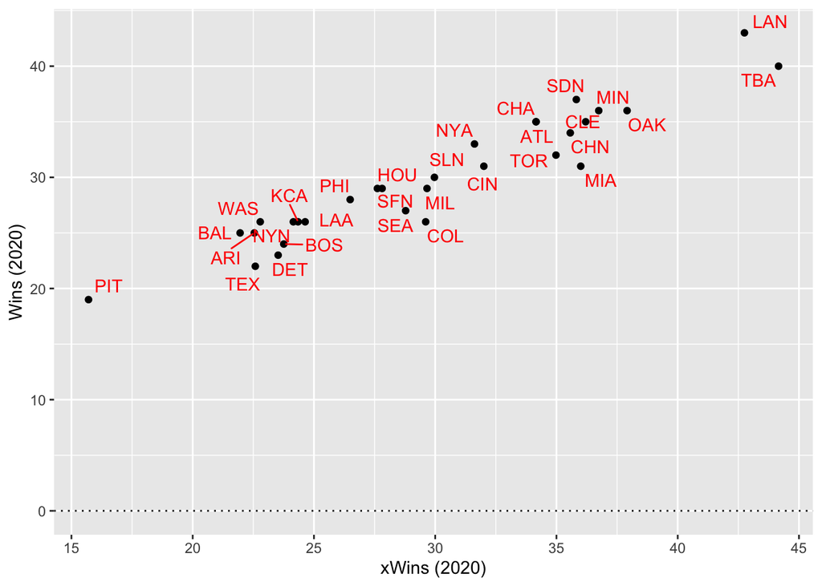

```r
base_plot <- ggplot(my_teams_augmented_covid, aes(x = xW, y = W)) + geom_point(alpha = 0.3) + geom_hline(yintercept = 0, linetype = 3) + xlab("xWins (2020)") + ylab("Wins (2020)")

highlight_teams <- my_teams_augmented_covid %>%
  arrange(desc(abs(W))) %>%
  tail(30)

base_plot + geom_point(data = highlight_teams, color = 'black') + geom_text_repel(data = highlight_teams, color = 'red', aes(label = paste(teamID)))
```

```r
my_teams_augmented_2021 <- my_teams_augmented_2021 %>%
  mutate(xGW = .resid*162, xW = xGW + W)
```

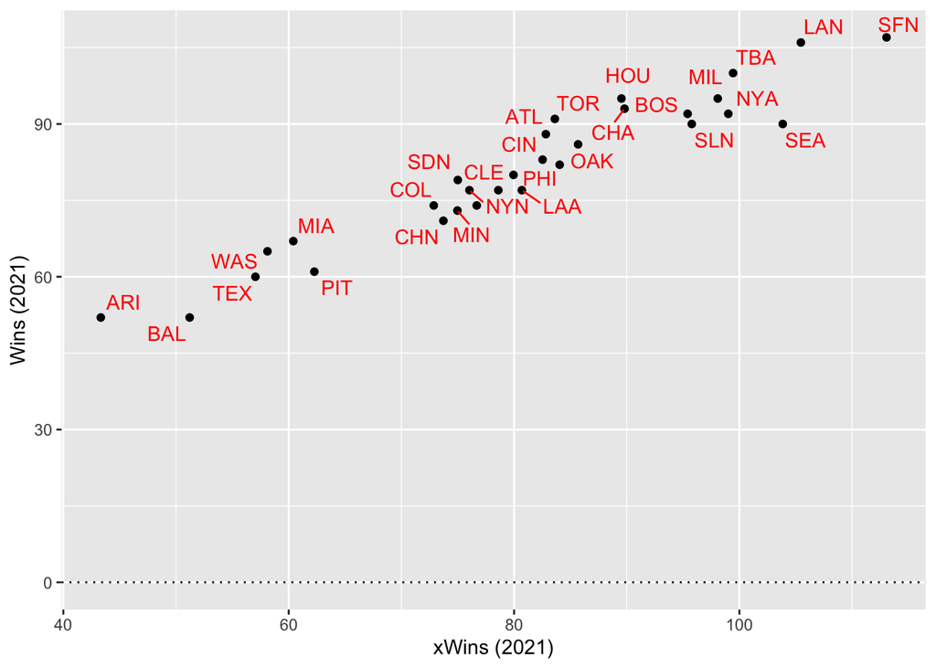

```r
base_plot <- ggplot(my_teams_augmented_2021, aes(x = xW, y = W)) + geom_point(alpha = 0.3) + geom_hline(yintercept = 0, linetype = 3) + xlab("xWins (2021)") + ylab("Wins (2021)")

highlight_teams <- my_teams_augmented_2021 %>%
  arrange(desc(abs(W))) %>%
  tail(30)

base_plot + geom_point(data = highlight_teams, color = 'black') + geom_text_repel(data = highlight_teams, color = 'red', aes(label = paste(teamID)))
```

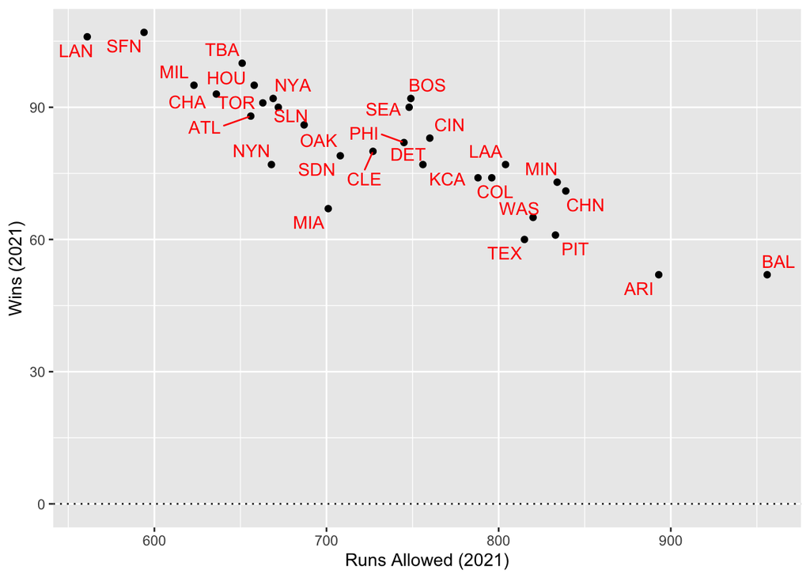

```r
base_plot <- ggplot(my_teams_augmented_2021, aes(x = RA, y = W)) + geom_point(alpha = 0.3) + geom_hline(yintercept = 0, linetype = 3) + xlab("Runs Allowed (2021)") + ylab("Wins (2021)")

highlight_teams <- my_teams_augmented_2021 %>%
  arrange(desc(abs(W))) %>%
  tail(30)

base_plot + geom_point(data = highlight_teams, color = 'black') + geom_text_repel(data = highlight_teams, color = 'red', aes(label = paste(teamID)))
```

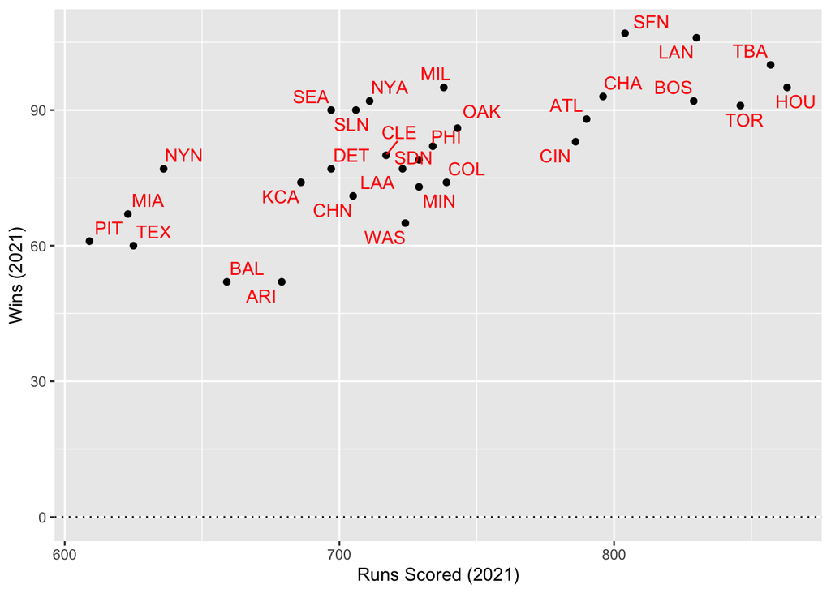

```r
base_plot <- ggplot(my_teams_augmented_2021, aes(x = R, y = W)) + geom_point(alpha = 0.3) + geom_hline(yintercept = 0, linetype = 3) + xlab("Runs Scored (2021)") + ylab("Wins (2021)")

highlight_teams <- my_teams_augmented_2021 %>%
  arrange(desc(abs(W))) %>%
  tail(30)

base_plot + geom_point(data = highlight_teams, color = 'black') + geom_text_repel(data = highlight_teams, color = 'red', aes(label = paste(teamID)))
```

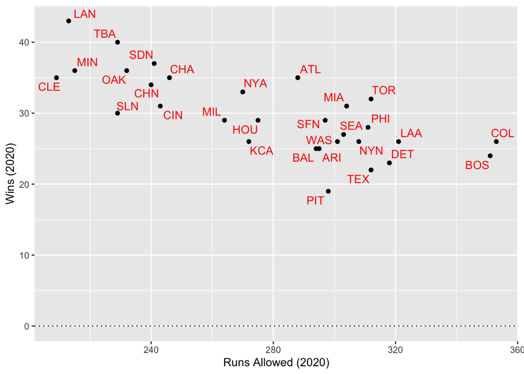

```r
base_plot <- ggplot(my_teams_augmented_covid, aes(x = RA, y = W)) + geom_point(alpha = 0.3) + geom_hline(yintercept = 0, linetype = 3) + xlab("Runs Allowed (2020)") + ylab("Wins (2020)")

highlight_teams <- my_teams_augmented_covid %>%
  arrange(desc(abs(W))) %>%
  tail(30)

base_plot + geom_point(data = highlight_teams, color = 'black') + geom_text_repel(data = highlight_teams, color = 'red', aes(label = paste(teamID)))
```

[figure not shown]

```r
base_plot <- ggplot(my_teams_augmented_covid, aes(x = R, y = W)) + geom_point(alpha = 0.3) + geom_hline(yintercept = 0, linetype = 3) + xlab("Runs Scored (2021)") + ylab("Wins (2021)")

highlight_teams <- my_teams_augmented_covid %>%
  arrange(desc(abs(W))) %>%
  tail(30)

base_plot + geom_point(data = highlight_teams, color = 'black') + geom_text_repel(data = highlight_teams, color = 'red', aes(label = paste(teamID)))
```